# what-I-learned-at-CMU

May 16, 2016

## CMU ≠

[figure not shown]

**But, the world doesn't know that.**

## Put the emPHAsis on the right sylLABle

Car**NE**gie Mellon

**The world doesn't know that, either.**

## But, Google does

[figure not shown]

## People like the Carnegie tartan

[figure not shown]

## Ken Koedinger can really hit a softball

[figure not shown]

## ACT-R does not mean

**A** **C**ognitive **T**heory

## MacMail 0.9 was good.

- So was Word 5.1a.
- Never upgrade.

## Ken Koedinger can really throw a football

[figure not shown]

## Think or thwim is not a bad approach to mentoring

[figure not shown]

## Ken Koedinger can…

do the can-can, better than a toucan can.

[figure not shown]

## GUI vs. command line ~

- Mac vs. Windows vs. *nix
- Blue state vs. Red state
- Nativism vs. empiricism
- Python vs. R
- JavaScript vs. a real language

## This World Wide Web is really a thing

[figure not shown]

## Gradient descent means

[figure not shown]

## The Brady Bunch

[figure not shown]

## The Brady Baker Bunch

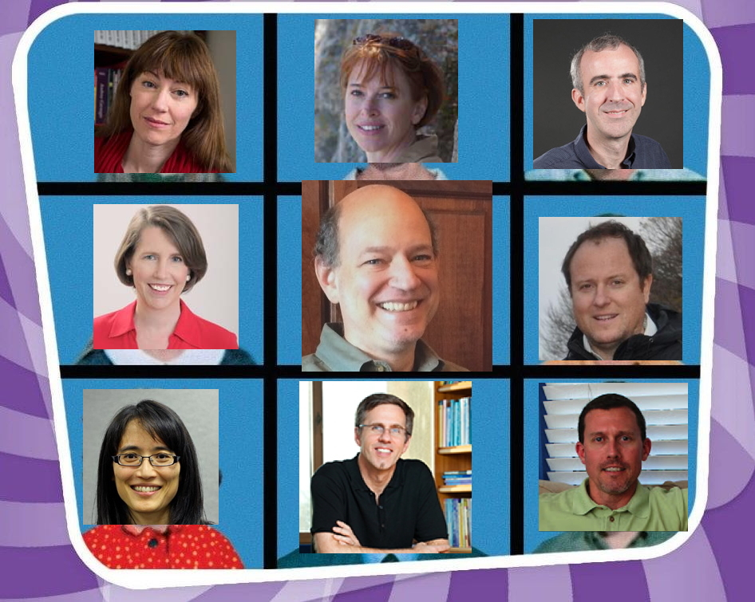

[video not shown]

## The Baker Bunch

Here's the story of a neural network  
Who was fighting for street cred in the hood.  
All the models had their productions.  
The network didn't feel good.

## The Baker Bunch

Here's the story, of SOARing models,  
that were 'splainin' cognition on their own.  
They were ACT*Rs in a play for Bobby Klatzky.  
But, they were all alone.

## The Baker Bunch

'Til the one day when the network reached its threshold.  
And the Psych-o's knew that it was much more than free lunch.  
That these geeks were really close as family.  
That's the way we all became the Baker Bunch.

## The Baker Bunch

The Baker Bunch, The Baker Bunch.  
That's the way we became the Baker Bunch.

## The Baker Bunch

[figure not shown]

http://github.com/rogilmore/cmu-psych-100/